# SVM Algorithm, Naïve Bayes and Decision Tree Algorithm for the Illness Study.

# Import Data

```python
#importing the libraries
import numpy as np
import matplotlib.pyplot as plt
import pandas as pd
import seaborn as sns
```

```python
import os
os.getcwd()
os.chdir('C:\\Users\\Admin\\Documents\\PythonDATA1200')
%pwd
```

```
'C:\\Users\\Admin\\Documents\\PythonDATA1200'
```

```python
import os
os.chdir('C:\\Users\\Admin\\Documents\\PythonDATA1200\\')
```

## Load Illness dataset

```python
#importing our cancer dataset
cds = pd.read_csv('illnessstudy.csv')
print(cds.shape)
cds.head()
```

```
(569, 31)
```

|  | radius_mean | texture_mean | perimeter_mean | area_mean | smoothness_mean | compactness_mean | concavity_mean | concave points_mean | symmetry_mean | fractal_dimension_mean | ... | texture_worst | perimeter_worst | area_worst | smoothness_worst | compactness_worst | concavity_worst | concave points_worst | symmetry_worst | fractal_dimension_worst | diagnosis |
| --- | --- | --- | --- | --- | --- | --- | --- | --- | --- | --- | --- | --- | --- | --- | --- | --- | --- | --- | --- | --- | --- |
| 0 | 17.99 | 10.38 | 122.80 | 1001.0 | 0.11840 | 0.27760 | 0.3001 | 0.14710 | 0.2419 | 0.07871 | ... | 17.33 | 184.60 | 2019.0 | 0.1622 | 0.6656 | 0.7119 | 0.2654 | 0.4601 | 0.11890 | M |
| 1 | 20.57 | 17.77 | 132.90 | 1326.0 | 0.08474 | 0.07864 | 0.0869 | 0.07017 | 0.1812 | 0.05667 | ... | 23.41 | 158.80 | 1956.0 | 0.1238 | 0.1866 | 0.2416 | 0.1860 | 0.2750 | 0.08902 | M |
| 2 | 19.69 | 21.25 | 130.00 | 1203.0 | 0.10960 | 0.15990 | 0.1974 | 0.12790 | 0.2069 | 0.05999 | ... | 25.53 | 152.50 | 1709.0 | 0.1444 | 0.4245 | 0.4504 | 0.2430 | 0.3613 | 0.08758 | M |
| 3 | 11.42 | 20.38 | 77.58 | 386.1 | 0.14250 | 0.28390 | 0.2414 | 0.10520 | 0.2597 | 0.09744 | ... | 26.50 | 98.87 | 567.7 | 0.2098 | 0.8663 | 0.6869 | 0.2575 | 0.6638 | 0.17300 | M |
| 4 | 20.29 | 14.34 | 135.10 | 1297.0 | 0.10030 | 0.13280 | 0.1980 | 0.10430 | 0.1809 | 0.05883 | ... | 16.67 | 152.20 | 1575.0 | 0.1374 | 0.2050 | 0.4000 | 0.1625 | 0.2364 | 0.07678 | M |

5 rows × 31 columns

## Statistics

```python
#Stats
cds.describe()
```

|  | radius_mean | texture_mean | perimeter_mean | area_mean | smoothness_mean | compactness_mean | concavity_mean | concave points_mean | symmetry_mean | fractal_dimension_mean | ... | radius_worst | texture_worst | perimeter_worst | area_worst | smoothness_worst | compactness_worst | concavity_worst | concave points_worst | symmetry_worst | fractal_dimension_worst |
| --- | --- | --- | --- | --- | --- | --- | --- | --- | --- | --- | --- | --- | --- | --- | --- | --- | --- | --- | --- | --- | --- |
| count | 569.000000 | 569.000000 | 569.000000 | 569.000000 | 569.000000 | 569.000000 | 569.000000 | 569.000000 | 569.000000 | 569.000000 | ... | 569.000000 | 569.000000 | 569.000000 | 569.000000 | 569.000000 | 569.000000 | 569.000000 | 569.000000 | 569.000000 | 569.000000 |
| mean | 14.127292 | 19.289649 | 91.969033 | 654.889104 | 0.096360 | 0.104341 | 0.088799 | 0.048919 | 0.181162 | 0.062798 | ... | 16.269190 | 25.677223 | 107.261213 | 880.583128 | 0.132369 | 0.254265 | 0.272188 | 0.114606 | 0.290076 | 0.083946 |
| std | 3.524049 | 4.301036 | 24.298981 | 351.914129 | 0.014064 | 0.052813 | 0.079720 | 0.038803 | 0.027414 | 0.007060 | ... | 4.833242 | 6.146258 | 33.602542 | 569.356993 | 0.022832 | 0.157336 | 0.208624 | 0.065732 | 0.061867 | 0.018061 |
| min | 6.981000 | 9.710000 | 43.790000 | 143.500000 | 0.052630 | 0.019380 | 0.000000 | 0.000000 | 0.106000 | 0.049960 | ... | 7.930000 | 12.020000 | 50.410000 | 185.200000 | 0.071170 | 0.027290 | 0.000000 | 0.000000 | 0.156500 | 0.055040 |
| 25% | 11.700000 | 16.170000 | 75.170000 | 420.300000 | 0.086370 | 0.064920 | 0.029560 | 0.020310 | 0.161900 | 0.057700 | ... | 13.010000 | 21.080000 | 84.110000 | 515.300000 | 0.116600 | 0.147200 | 0.114500 | 0.064930 | 0.250400 | 0.071460 |
| 50% | 13.370000 | 18.840000 | 86.240000 | 551.100000 | 0.095870 | 0.092630 | 0.061540 | 0.033500 | 0.179200 | 0.061540 | ... | 14.970000 | 25.410000 | 97.660000 | 686.500000 | 0.131300 | 0.211900 | 0.226700 | 0.099930 | 0.282200 | 0.080040 |
| 75% | 15.780000 | 21.800000 | 104.100000 | 782.700000 | 0.105300 | 0.130400 | 0.130700 | 0.074000 | 0.195700 | 0.066120 | ... | 18.790000 | 29.720000 | 125.400000 | 1084.000000 | 0.146000 | 0.339100 | 0.382900 | 0.161400 | 0.317900 | 0.092080 |
| max | 28.110000 | 39.280000 | 188.500000 | 2501.000000 | 0.163400 | 0.345400 | 0.426800 | 0.201200 | 0.304000 | 0.097440 | ... | 36.040000 | 49.540000 | 251.200000 | 4254.000000 | 0.222600 | 1.058000 | 1.252000 | 0.291000 | 0.663800 | 0.207500 |

8 rows × 30 columns

## Key Stats

```python
#Key Stats
pd.options.display.max_rows = None
cds.groupby(['diagnosis']).describe().transpose()
```

|  | diagnosis | B | M |
| --- | --- | --- | --- |
| radius_mean | count | 357.000000 | 212.000000 |
|  | mean | 12.146524 | 17.462830 |
|  | std | 1.780512 | 3.203971 |
|  | min | 6.981000 | 10.950000 |
|  | 25% | 11.080000 | 15.075000 |
|  | 50% | 12.200000 | 17.325000 |
|  | 75% | 13.370000 | 19.590000 |
|  | max | 17.850000 | 28.110000 |
| texture_mean | count | 357.000000 | 212.000000 |
|  | mean | 17.914762 | 21.604906 |
|  | std | 3.995125 | 3.779470 |
|  | min | 9.710000 | 10.380000 |
|  | 25% | 15.150000 | 19.327500 |
|  | 50% | 17.390000 | 21.460000 |
|  | 75% | 19.760000 | 23.765000 |
|  | max | 33.810000 | 39.280000 |
| perimeter_mean | count | 357.000000 | 212.000000 |
|  | mean | 78.075406 | 115.365377 |
|  | std | 11.807438 | 21.854653 |
|  | min | 43.790000 | 71.900000 |
|  | 25% | 70.870000 | 98.745000 |
|  | 50% | 78.180000 | 114.200000 |
|  | 75% | 86.100000 | 129.925000 |
|  | max | 114.600000 | 188.500000 |
| area_mean | count | 357.000000 | 212.000000 |
|  | mean | 462.790196 | 978.376415 |
|  | std | 134.287118 | 367.937978 |
|  | min | 143.500000 | 361.600000 |
|  | 25% | 378.200000 | 705.300000 |
|  | 50% | 458.400000 | 932.000000 |

[output cut: 210 more lines]

# Data Cleaning

## Checking for Null and Incomplete

```python
#Count the empty (NaN, NAN, na) values in each column
cds.isna().sum()
```

```
radius_mean                0
texture_mean               0
perimeter_mean             0
area_mean                  0
smoothness_mean            0
compactness_mean           0
concavity_mean             0
concave points_mean        0
symmetry_mean              0
fractal_dimension_mean     0
radius_se                  0
texture_se                 0
perimeter_se               0
area_se                    0
smoothness_se              0
compactness_se             0
concavity_se               0
concave points_se          0
symmetry_se                0
fractal_dimension_se       0
radius_worst               0
texture_worst              0
perimeter_worst            0
area_worst                 0
smoothness_worst           0
compactness_worst          0
concavity_worst            0
concave points_worst       0
symmetry_worst             0
fractal_dimension_worst    0
diagnosis                  0
dtype: int64
```

NO NULLS FOUND.The result reveals a total of 569 entries in the dataset. Generally, the columns tied with data type “int64” denotes numerical data.

## Dropping Duplicates

```python
#Check and drop duplicates in the datat set
cds=cds.drop_duplicates()
print(cds.shape)
```

```
(569, 31)
```

DATA is CLEAN.NO Duplicates Observed.

## Shape of the data set

```python
print(cds.shape)
cds.head()
```

```
(569, 31)
```

|  | radius_mean | texture_mean | perimeter_mean | area_mean | smoothness_mean | compactness_mean | concavity_mean | concave points_mean | symmetry_mean | fractal_dimension_mean | ... | texture_worst | perimeter_worst | area_worst | smoothness_worst | compactness_worst | concavity_worst | concave points_worst | symmetry_worst | fractal_dimension_worst | diagnosis |
| --- | --- | --- | --- | --- | --- | --- | --- | --- | --- | --- | --- | --- | --- | --- | --- | --- | --- | --- | --- | --- | --- |
| 0 | 17.99 | 10.38 | 122.80 | 1001.0 | 0.11840 | 0.27760 | 0.3001 | 0.14710 | 0.2419 | 0.07871 | ... | 17.33 | 184.60 | 2019.0 | 0.1622 | 0.6656 | 0.7119 | 0.2654 | 0.4601 | 0.11890 | M |
| 1 | 20.57 | 17.77 | 132.90 | 1326.0 | 0.08474 | 0.07864 | 0.0869 | 0.07017 | 0.1812 | 0.05667 | ... | 23.41 | 158.80 | 1956.0 | 0.1238 | 0.1866 | 0.2416 | 0.1860 | 0.2750 | 0.08902 | M |
| 2 | 19.69 | 21.25 | 130.00 | 1203.0 | 0.10960 | 0.15990 | 0.1974 | 0.12790 | 0.2069 | 0.05999 | ... | 25.53 | 152.50 | 1709.0 | 0.1444 | 0.4245 | 0.4504 | 0.2430 | 0.3613 | 0.08758 | M |
| 3 | 11.42 | 20.38 | 77.58 | 386.1 | 0.14250 | 0.28390 | 0.2414 | 0.10520 | 0.2597 | 0.09744 | ... | 26.50 | 98.87 | 567.7 | 0.2098 | 0.8663 | 0.6869 | 0.2575 | 0.6638 | 0.17300 | M |
| 4 | 20.29 | 14.34 | 135.10 | 1297.0 | 0.10030 | 0.13280 | 0.1980 | 0.10430 | 0.1809 | 0.05883 | ... | 16.67 | 152.20 | 1575.0 | 0.1374 | 0.2050 | 0.4000 | 0.1625 | 0.2364 | 0.07678 | M |

5 rows × 31 columns

# Visualizing Data

## Heatmap

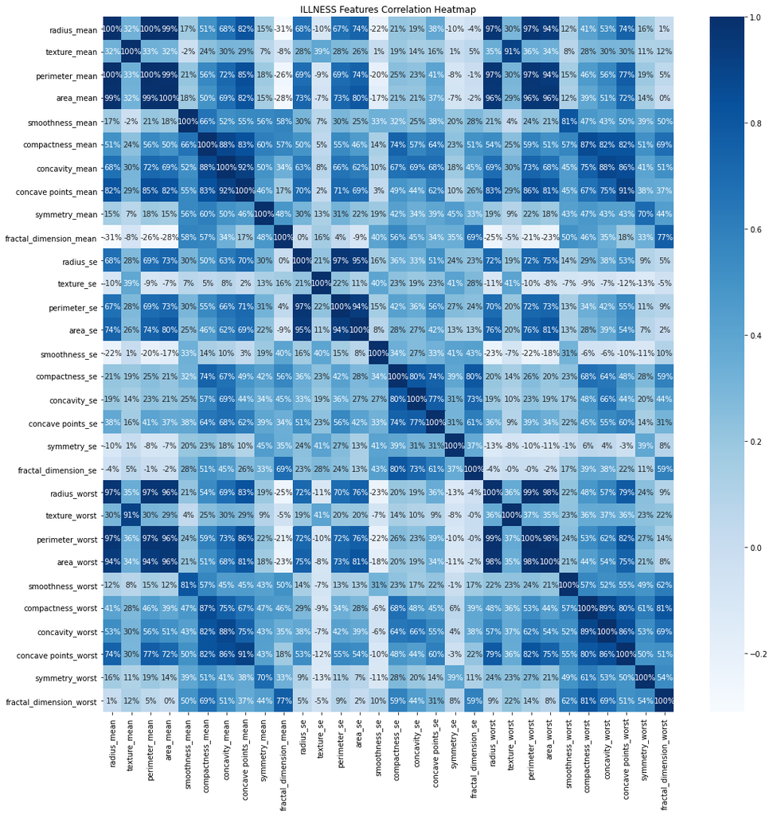

```python
plt.figure(figsize=(17,17))
sns.heatmap(cds.corr(), annot=True, cmap='Blues', fmt='.0%')
plt.title("ILLNESS Features Correlation Heatmap")
```

## Count for Class

[figure not shown]

```python
#Visualize the cancer count
sns.countplot(cds['diagnosis'],label="Count")
plt.title('Plot for Class: (2 for benign, 4 for malignant)')
```

357 are labeled “B” (benign) and 212 as “M” (malignant).

# Creating the variables

```python
#Create x and y variables
x = cds.drop('diagnosis', axis=1).to_numpy()
y = cds['diagnosis'].to_numpy()
```

# Creating Test and Train data

```python
#Create Training and Test Datasets
from sklearn.model_selection import train_test_split
x_train, x_test,y_train, y_test = train_test_split(x, y, stratify = y,test_size=0.2,random_state=0)
```

# Scaling the Data

```python
#Scale the Data
from sklearn.preprocessing import StandardScaler
sc = StandardScaler()
x_train2 = sc.fit_transform(x_train)
x_test2 = sc.transform(x_test)
```

# Creating the model - SVM & Naive Bayes

```python
#Script for SVM and NB
from sklearn.svm import SVC
from sklearn.naive_bayes import GaussianNB
from sklearn.metrics import classification_report, confusion_matrix

for name,method in [('SVM', SVC(kernel='linear',random_state=0)),('Naive Bayes',GaussianNB())]:
    method.fit(x_train2,y_train)
    predict = method.predict(x_test2)
    print('\nEstimator: {}'.format(name))
    print(confusion_matrix(y_test,predict))
    print(classification_report(y_test,predict))
```

```
Estimator: SVM
[[71  1]
 [ 5 37]]
              precision    recall  f1-score   support

           B       0.93      0.99      0.96        72
           M       0.97      0.88      0.93        42

    accuracy                           0.95       114
   macro avg       0.95      0.93      0.94       114
weighted avg       0.95      0.95      0.95       114


Estimator: Naive Bayes
[[65  7]
 [ 4 38]]
              precision    recall  f1-score   support

           B       0.94      0.90      0.92        72
           M       0.84      0.90      0.87        42

    accuracy                           0.90       114
   macro avg       0.89      0.90      0.90       114
weighted avg       0.91      0.90      0.90       114
```

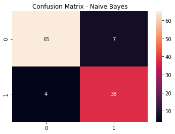

```python
#Confusion Matrix - Naive Bayes
cmg = confusion_matrix(y_test,predict)
sns.heatmap(cmg, annot=True)
plt.title('Confusion Matrix - Naive Bayes')
```

# Finding the best fit for SVM using Non-linear

[output not shown]

[output not shown]

[output not shown]

[output cut: 178 more lines]

```
[CV] ..... C=1000, gamma=0.001, kernel=rbf, score=0.934, total=   0.0s
[CV] C=1000, gamma=0.001, kernel=rbf .................................
[CV] ..... C=1000, gamma=0.001, kernel=rbf, score=0.901, total=   0.0s
[CV] C=1000, gamma=0.001, kernel=rbf .................................
[CV] ..... C=1000, gamma=0.001, kernel=rbf, score=0.923, total=   0.0s
[[66  6]
 [ 3 39]]
              precision    recall  f1-score   support

           B       0.96      0.92      0.94        72
           M       0.87      0.93      0.90        42

    accuracy                           0.92       114
   macro avg       0.91      0.92      0.92       114
weighted avg       0.92      0.92      0.92       114
```

[output not shown]

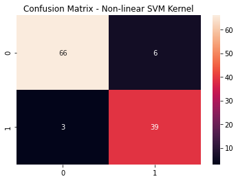

```python
#find the best hyper parameters using non-linear
from sklearn.model_selection import GridSearchCV
param_grid = {'C':[0.1,1,10,100,1000],'gamma':[1,0.1,0.01,0.001,0.001], 'kernel':['rbf']}
grid = GridSearchCV(SVC(),param_grid,verbose = 4)
grid.fit(x_train,y_train)
grid.best_params_
grid.best_estimator_
grid_predictions = grid.predict(x_test)
cmG = confusion_matrix(y_test,grid_predictions)
sns.heatmap(cmG, annot=True)
plt.title('Confusion Matrix - Non-linear SVM Kernel')
print(confusion_matrix(y_test,grid_predictions))
print(classification_report(y_test,grid_predictions))
```

[output not shown]

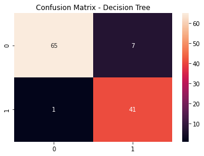

```python
#Script for Decision Tree
from sklearn.tree import DecisionTreeClassifier

for name,method in [('DT', DecisionTreeClassifier(random_state=0))]:
    method.fit(x_train2,y_train)
    predict = method.predict(x_test2)
    print('\nEstimator: {}'.format(name))
    print(confusion_matrix(y_test,predict))
    print(classification_report(y_test,predict,target_names=target_names))
    cmG = confusion_matrix(y_test,predict)
    sns.heatmap(cmG, annot=True)
    plt.title('Confusion Matrix - Decision Tree')
```

Conclusion :  
92.9% for Decision tree, 90.3% for Naïve Bayes, 94.7% for SVM Linear and 92.1% for SVM Non-Linear model. Hence, of all three models, I recommend SVM-Linear model to be utilized for illness study dataset to Mr. John Hughes for his analysis.